# Global Development Analysis: GDP per Capita and Maternal Mortality in 2010

Data Analysis Report

2025-08-30

## Introduction

This report analyzes two critical global development indicators for the year 2010:

1. **GDP per capita** - Economic prosperity measure
2. **Maternal mortality ratio** - Health outcome indicator (deaths per 100,000 live births)

By examining these indicators at a single point in time, we can understand the global distribution of development and explore potential relationships between economic prosperity and health outcomes.

## Data Loading and Preparation

The GDP dataset contains 195 countries with data spanning 301 years, while the maternal mortality dataset covers 189 countries.

## Data Subsetting for 2010

## World Map Visualizations

### 1. GDP per Capita World Map (2010)

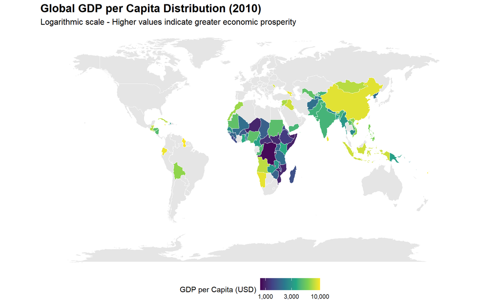

### 2. Maternal Mortality World Map (2010)

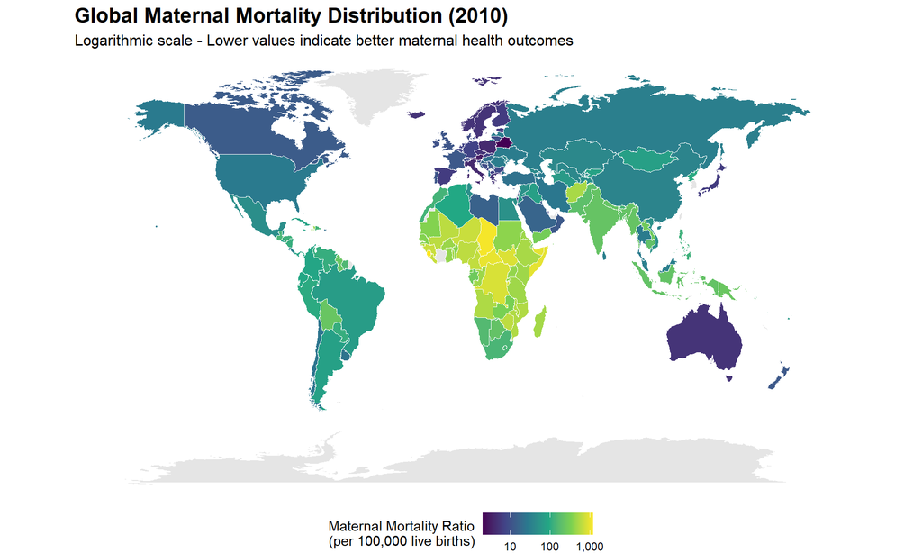

**Key Observations:** - Lowest maternal mortality rates in developed countries (Europe, North America, Oceania) - Highest rates in Sub-Saharan Africa and parts of South Asia - Clear inverse relationship with economic development visible

## Data Merging and Correlation Analysis

```
## Countries with both indicators in 2010: 90
```

```
## Pearson correlation coefficient (r): -0.658
```

```
## P-value: 0
```

## Scatterplot: Relationship Between GDP and Maternal Mortality

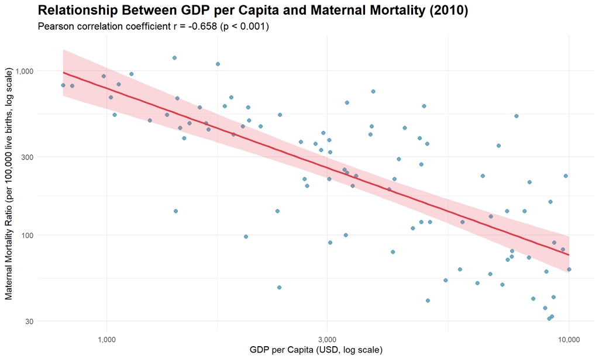

## Statistical Summary

| Metric | Value |
| --- | --- |
| Number of Countries | 90.0 |
| Mean GDP per Capita (USD) | 4317.0 |
| Median GDP per Capita (USD) | 3430.0 |
| Mean Maternal Mortality | 331.8 |
| Median Maternal Mortality | 245.0 |

## Interpretation of the Relationship

The scatterplot reveals a **strong negative correlation** between GDP per capita and maternal mortality rates in 2010:

- **Correlation coefficient (r) = -0.658**: This indicates a strong negative relationship
- **Statistical significance**: The p-value < 0.001 confirms this relationship is not due to chance
- **Direction**: As GDP per capita increases, maternal mortality rates decrease
- **Strength**: The correlation explains approximately 43.3% of the variance in maternal mortality rates

### Key Insights:

1. **Economic Development and Health**: Higher economic prosperity is strongly associated with better maternal health outcomes
2. **Global Health Disparities**: The relationship highlights the significant health inequalities between developed and developing nations
3. **Development Priorities**: Economic growth appears to be a crucial factor in improving maternal health, though not the only one
4. **Policy Implications**: Development strategies that focus on economic growth may have important positive spillover effects on maternal health outcomes

### Limitations:

- **Correlation vs. Causation**: This analysis shows association, not causation
- **Other Factors**: Maternal mortality is influenced by many factors beyond GDP (healthcare systems, education, cultural factors, etc.)
- **Data Quality**: Some countries may have incomplete or inaccurate reporting
- **Logarithmic Transformation**: The log scales help visualize the relationship but may mask some nuances in the data

This analysis demonstrates that economic development and maternal health are closely intertwined, suggesting that comprehensive development strategies should consider both economic and health dimensions together.

### Reflections on using the AI agent:

1. **Amazing capacity to detect and fix errors**: When there were problems, the AI agent was able to detect and fix them quickly. I liked that after remedying the issues, it gave me a summary of what it had done to the code so that I could learn (and keep in touch with the code).
2. **Difficulties I encountered**: My main challenge was not interacting with the agent but finding how to start new projects and setting up which panes/windows go where. I still dont have a good feel for how to set up the best view, nor how to save files.
3. **Concerns**: The agent seems to create new mardown files over and over, I dont know much about this but I wonder about the computational energy it takes to do this and whether I should be mindful of not creating too much work.